# NYC EDA

### Have a look at the data

We have 7 months of data, from 2014/07/01 till 2015/01/31.

NOTE : Scale data to bring to manageable levels.

|  | timestamp | value |
| --- | --- | --- |
| 1 | 2014-07-01 00:00:00 | 10844 |
| 2 | 2014-07-01 00:30:00 | 8127 |
| 3 | 2014-07-01 01:00:00 | 6210 |
| 4 | 2014-07-01 01:30:00 | 4656 |
| 5 | 2014-07-01 02:00:00 | 3820 |
| 6 | 2014-07-01 02:30:00 | 2873 |

|  | timestamp | value |
| --- | --- | --- |
| 10315 | 2015-01-31 21:00:00 | 23719 |
| 10316 | 2015-01-31 21:30:00 | 24670 |
| 10317 | 2015-01-31 22:00:00 | 25721 |
| 10318 | 2015-01-31 22:30:00 | 27309 |
| 10319 | 2015-01-31 23:00:00 | 26591 |
| 10320 | 2015-01-31 23:30:00 | 26288 |

```
[1] 10320     2
```

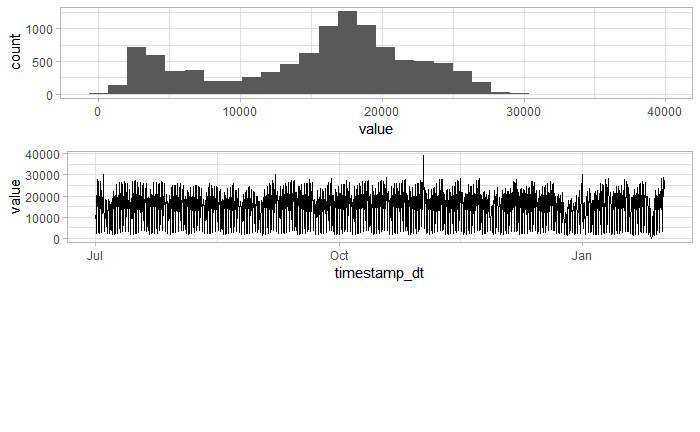

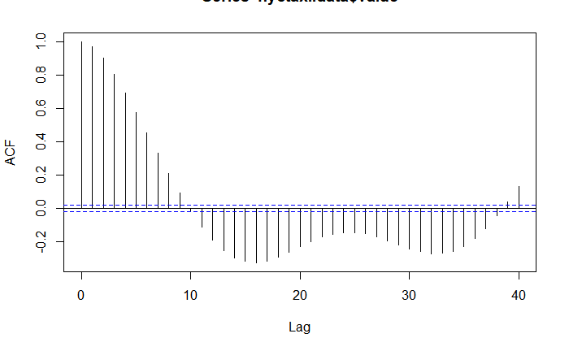

Plot the graphs for just one week

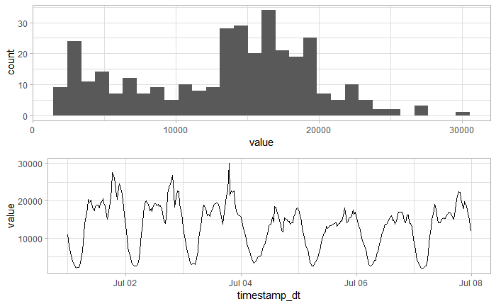

### Visualise the anomalies

| timestamp | value | timestamp_dt | flag_anomaly |
| --- | --- | --- | --- |
| 2014-11-01 19:00:00 | 28398 | 2014-11-01 19:00:00 | TRUE |
| 2014-11-27 15:30:00 | 15255 | 2014-11-27 15:30:00 | TRUE |
| 2014-12-25 15:00:00 | 12039 | 2014-12-25 15:00:00 | TRUE |
| 2015-01-01 01:00:00 | 30236 | 2015-01-01 01:00:00 | TRUE |
| 2015-01-27 00:00:00 | 109 | 2015-01-27 00:00:00 | TRUE |

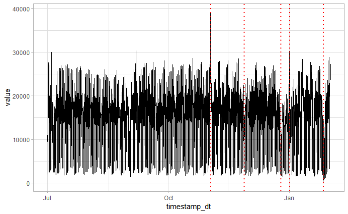

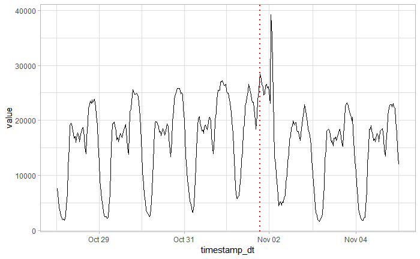

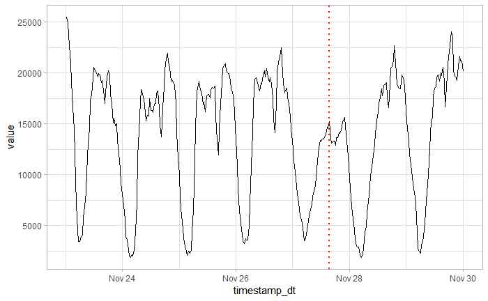

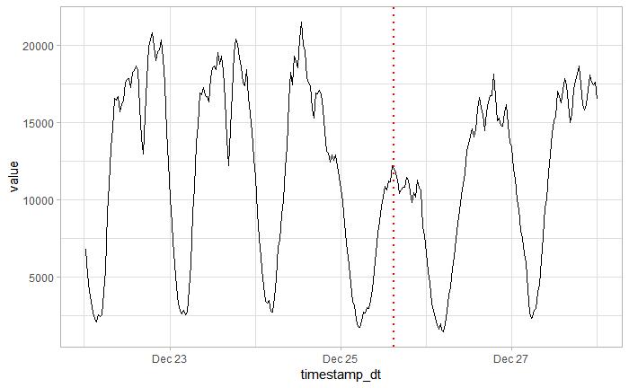

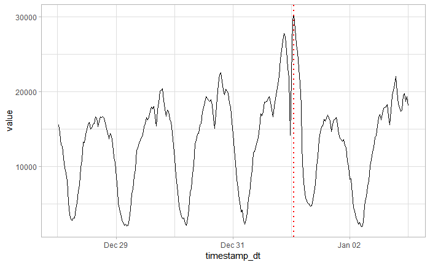

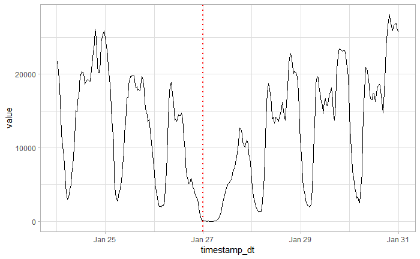

## Tests for Stationarity

```
    KPSS Test for Level Stationarity

data:  nyctaxi.data$value
KPSS Level = 0.27408, Truncation lag parameter = 12, p-value = 0.1
```

```
    Augmented Dickey-Fuller Test

data:  nyctaxi.data$value
Dickey-Fuller = -27.911, Lag order = 10, p-value = 0.01
alternative hypothesis: stationary
```

The signal is definitely stationary.

##### Test for Heteroskedasticity and Stationarity

We can use the Phillipsâ“Perron test to test for Stationarity while accounting for heteroskedasticity.

https://en.wikipedia.org/wiki/Phillips%E2%80%93Perron_test https://rdrr.io/cran/aTSA/man/pp.test.html

The test is similar to ADF in terms of hypo testing. i.e., it’s a unit root test, alternate hypo is stationarity

```
    Phillips-Perron Unit Root Test

data:  nyctaxi.data$value
Dickey-Fuller Z(alpha) = -1002.9, Truncation lag parameter = 12, p-value = 0.01
alternative hypothesis: stationary
```

## ————————————————————————————

# Test and compensate for Seasonality and Trend

Frequency is the expected repitition window.

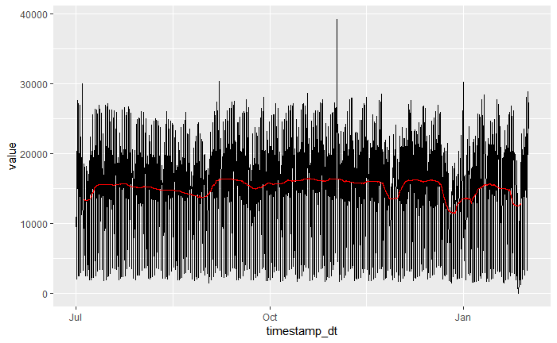

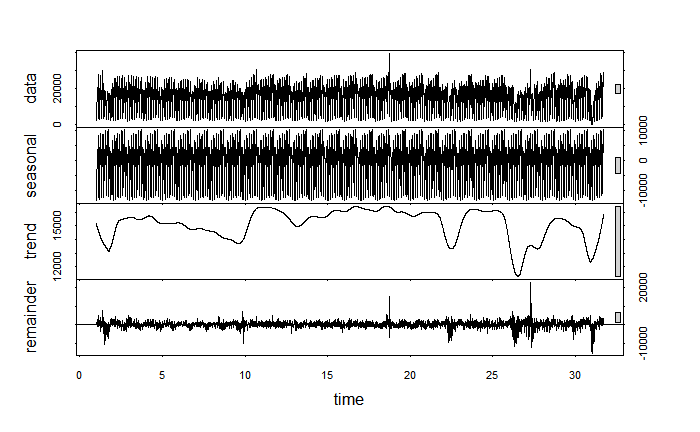

Eyeballing the graph -> it seems to be an additive model, i.e., data = seasonal + trend + remainder

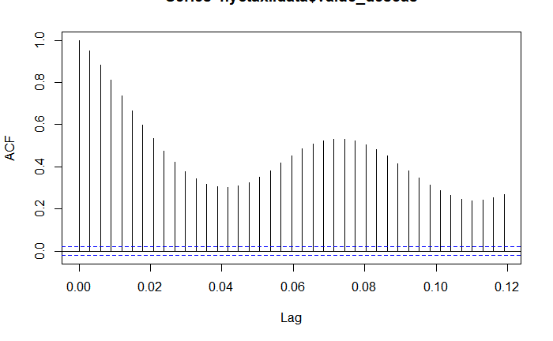

[figure not shown]

```
    KPSS Test for Level Stationarity

data:  nyctaxi.data$value_deseas
KPSS Level = 2.3073, Truncation lag parameter = 12, p-value = 0.01


    Augmented Dickey-Fuller Test

data:  nyctaxi.data$value_deseas
Dickey-Fuller = -17.722, Lag order = 10, p-value = 0.01
alternative hypothesis: stationary


    Phillips-Perron Unit Root Test

data:  nyctaxi.data$value
Dickey-Fuller Z(alpha) = -1002.9, Truncation lag parameter = 12, p-value = 0.01
alternative hypothesis: stationary
```

# Modelling the data

Split the data into train and test.

```r
nyc.subsamp <- nyctaxi.data[(nyctaxi.data$timestamp_dt > as.POSIXct("2014-10-01 00:00:00"))&
                              (nyctaxi.data$timestamp_dt <= as.POSIXct("2014-12-01 00:00:00")),]
train.data <- nyc.subsamp[nyc.subsamp$timestamp_dt < as.POSIXct("2014-10-28 00:00:00"),]
test.data <- nyc.subsamp[(nyc.subsamp$timestamp_dt >= as.POSIXct("2014-10-28 00:00:00"))&
                            (nyc.subsamp$timestamp_dt <= as.POSIXct("2014-10-30 00:00:00")),]
```

Now let’s have a look at the Auto arima model with seasonal flag enabled

```r
train.data.daily.ts = ts(as.numeric(train.data$value),
                         start=c(1,1),
                         frequency = 24*2*7)
autoplot(train.data.daily.ts)
```

[output not shown]

NOTE : this takes a while to run

```r
arima.model.auto <- auto.arima(train.data.daily.ts, seasonal = TRUE)
```

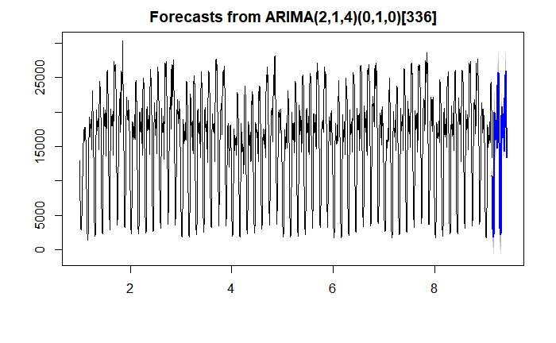

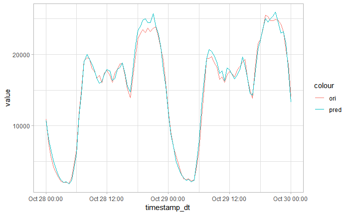

Thoughts :

Update the model each week? Clear predictable trend for a particular week

ToDo : Justify time windows chosen to model pattern ToDo : Find appropriate trigger to re-train model. Perhaps increasing cumulative residual error in a window?

## ——————————————————————————————————————

# Residual analysis

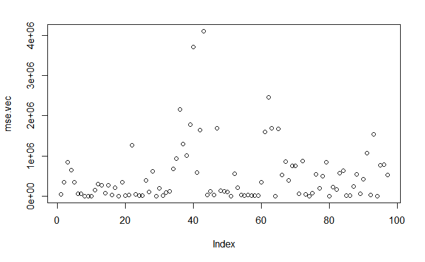

```r
mse.vec <- (as.vector(test.data$value) - as.vector(arima.model.auto.fcast$mean))^2
plot(mse.vec)
```

```r
(recursive.mse <- mean(mse.vec))
```

```
[1] 510505
```

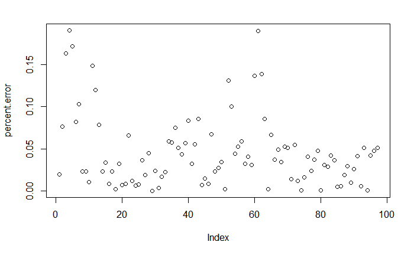

```r
percent.error <- abs(as.vector(test.data$value) - as.vector(arima.model.auto.fcast$mean))/as.vector(test.data$value)
plot(percent.error)
```

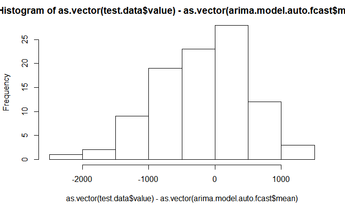

```r
hist(as.vector(test.data$value) - as.vector(arima.model.auto.fcast$mean))
```

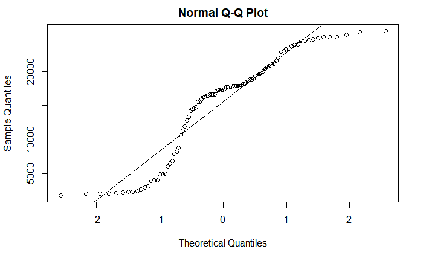

```r
qqnorm(as.vector(arima.model.auto.fcast$mean))
qqline(as.vector(arima.model.auto.fcast$mean))
```

```r
ks.test(arima.model.auto.fcast$mean, "pnorm")
```

```
    One-sample Kolmogorov-Smirnov test

data:  arima.model.auto.fcast$mean
D = 1, p-value = 5.551e-16
alternative hypothesis: two-sided
```

```r
cutoff <- 0.5
# get index of error terms above cut off
percent.error > cutoff
```

[output not shown]